# examples_1203

$$12-2$$

$$12-2=10$$

$$7+12$$

$$7+12=19$$

$$\frac{30}{10}$$

$$\frac{30}{10}=3$$

$$18-11$$

$$18-11=7$$

$$8-5$$

$$8-5=3$$

$$14-5$$

$$14-5=9$$

$$10+10$$

$$10+10=20$$

$$21-9$$

$$21-9=12$$

$$(10)+(-9)$$

$$(10)+(-9)=1$$

$$(-7)+(-1)$$

$$(-7)+(-1)=-8$$

$$\frac{24}{-8}$$

$$\frac{24}{-8}=-3$$

$$(17)-(10)$$

$$(17)-(10)=7$$

$$\frac{45}{-9}$$

$$\frac{45}{-9}=-5$$

$$(16)-(10)$$

$$(16)-(10)=6$$

$$(-2)\cdot (2)$$

$$(-2)\cdot (2)=-4$$

$$\frac{-3}{-1}$$

$$\frac{-3}{-1}=3$$

What value of $x$ satisfies the equation?
$$26=9 x-10$$

$$26=9 x-10$$

Add 10 to both sides.

$$36=9x$$

Divide both sides by 9

$$4=x$$

Switch sides.

$$x=4$$

What value of $x$ satisfies the equation?
$$15=2 x-9$$

$$15=2 x-9$$

Add 9 to both sides.

$$24=2x$$

Divide both sides by 2

$$12=x$$

Switch sides.

$$x=12$$

What value of $x$ satisfies the equation?
$$17=5 x+2$$

$$17=5 x+2$$

Subtract 2 from both sides.

$$15=5x$$

Divide both sides by 5

$$3=x$$

Switch sides.

$$x=3$$

What value of $x$ satisfies the equation?
$$45=(x-3)\cdot 9$$

$$45=(x-3)\cdot 9$$

Divide both sides by 9.

$$5=x-3$$

Add 3 to both sides

$$8=x$$

Switch sides.

$$x=8$$

What value of $x$ satisfies the equation?
$$8=\frac{x}{2}+3$$

$$8=\frac{x}{2}+3$$

Subtract 3 from both sides.

$$5=\frac{x}{2}$$

Multiply both sides by 2

$$10=x$$

Switch sides.

$$x=10$$

What value of $x$ satisfies the equation?
$$2=\frac{x+8}{9}$$

$$2=\frac{x+8}{9}$$

Multiply both sides by 9.

$$18=x+8$$

Subtract 8 from both sides

$$10=x$$

Switch sides.

$$x=10$$

What value of $x$ satisfies the equation?
$$33=8 x+9$$

$$33=8 x+9$$

Subtract 9 from both sides.

$$24=8x$$

Divide both sides by 8

$$3=x$$

Switch sides.

$$x=3$$

What value of $x$ satisfies the equation?
$$68=6 x+2$$

$$68=6 x+2$$

Subtract 2 from both sides.

$$66=6x$$

Divide both sides by 6

$$11=x$$

Switch sides.

$$x=11$$

Consider the function below.

$$f(x)~=~{5}x-{2}x^{2}+{9}x-{4}+{6}-{8}x+{8}x^{2}-{3}x^{2}+{7}$$

By combining [like terms](https://en.wikipedia.org/wiki/Like_terms#Example), we can create a simplified [quadratic function](https://en.wikipedia.org/wiki/Quadratic_function) in standard form.

$$f(x)~=~ax^2+bx+c$$

Find the values of $a$, $b$, and $c$.

- $a=$
- $b=$
- $c=$

Combine the quadratic terms. The quadratic coefficients are {-2 , 8 , -3}, and their sum is 3.

$${-2}x^{2}+{8}x^{2}-{3}x^{2}~\equiv~
3x^2$$

Combine the linear terms. The linear coefficients are {5 , 9 , -8}, and their sum is 6.

$${5}x+{9}x-{8}x~\equiv~ 6x$$

Combine the constant terms. The constant coefficients are {-4 , 6 , 7}, and their sum is 9.

$${-4}+{6}+{7}~\equiv~ 9$$

Thus, we can write the function in standard form.

$$f(x)~=~{3}x^{2}+{6}x+{9}$$

We can now identify the values of $a$ and $b$ and $c$.

$$a=3$$
$$b=6$$
$$c=9$$

Consider the function below.

$$f(x)~=~{6}x^{2}+x+{7}-{9}-{5}x^{2}-{2}x-{8}x-{7}x^{2}+{5}$$

By combining [like terms](https://en.wikipedia.org/wiki/Like_terms#Example), we can create a simplified [quadratic function](https://en.wikipedia.org/wiki/Quadratic_function) in standard form.

$$f(x)~=~ax^2+bx+c$$

Find the values of $a$, $b$, and $c$.

- $a=$
- $b=$
- $c=$

Combine the quadratic terms. The quadratic coefficients are {6 , -5 , -7}, and their sum is -6.

$${6}x^{2}-{5}x^{2}-{7}x^{2}~\equiv~
-6x^2$$

Combine the linear terms. The linear coefficients are {1 , -2 , -8}, and their sum is -9.

$$x-{2}x-{8}x~\equiv~ -9x$$

Combine the constant terms. The constant coefficients are {7 , -9 , 5}, and their sum is 3.

$${7}-{9}+{5}~\equiv~ 3$$

Thus, we can write the function in standard form.

$$f(x)~=~{-6}x^{2}-{9}x+{3}$$

We can now identify the values of $a$ and $b$ and $c$.

$$a=-6$$
$$b=-9$$
$$c=3$$

Consider the function below.

$$f(x)~=~{4}-{7}-{8}x^{2}-{4}x^{2}+{3}x^{2}+{9}-{5}x+{6}x+{7}x$$

By combining [like terms](https://en.wikipedia.org/wiki/Like_terms#Example), we can create a simplified [quadratic function](https://en.wikipedia.org/wiki/Quadratic_function) in standard form.

$$f(x)~=~ax^2+bx+c$$

Find the values of $a$, $b$, and $c$.

- $a=$
- $b=$
- $c=$

Combine the quadratic terms. The quadratic coefficients are {-8 , -4 , 3}, and their sum is -9.

$${-8}x^{2}-{4}x^{2}+{3}x^{2}~\equiv~
-9x^2$$

Combine the linear terms. The linear coefficients are {-5 , 6 , 7}, and their sum is 8.

$${-5}x+{6}x+{7}x~\equiv~ 8x$$

Combine the constant terms. The constant coefficients are {4 , -7 , 9}, and their sum is 6.

$${4}-{7}+{9}~\equiv~ 6$$

Thus, we can write the function in standard form.

$$f(x)~=~{-9}x^{2}+{8}x+{6}$$

We can now identify the values of $a$ and $b$ and $c$.

$$a=-9$$
$$b=8$$
$$c=6$$

Consider the function below.

$$f(x)~=~{-2}x+{7}+{3}x^{2}-{7}x-{3}+{5}-{9}x^{2}+{2}x^{2}+{6}x$$

By combining [like terms](https://en.wikipedia.org/wiki/Like_terms#Example), we can create a simplified [quadratic function](https://en.wikipedia.org/wiki/Quadratic_function) in standard form.

$$f(x)~=~ax^2+bx+c$$

Find the values of $a$, $b$, and $c$.

- $a=$
- $b=$
- $c=$

Combine the quadratic terms. The quadratic coefficients are {3 , -9 , 2}, and their sum is -4.

$${3}x^{2}-{9}x^{2}+{2}x^{2}~\equiv~
-4x^2$$

Combine the linear terms. The linear coefficients are {-2 , -7 , 6}, and their sum is -3.

$${-2}x-{7}x+{6}x~\equiv~ -3x$$

Combine the constant terms. The constant coefficients are {7 , -3 , 5}, and their sum is 9.

$${7}-{3}+{5}~\equiv~ 9$$

Thus, we can write the function in standard form.

$$f(x)~=~{-4}x^{2}-{3}x+{9}$$

We can now identify the values of $a$ and $b$ and $c$.

$$a=-4$$
$$b=-3$$
$$c=9$$

Consider the function below.

$$f(x)~=~{8}x^{2}-{3}+x^{2}+{4}x-{4}-{6}x^{2}-{9}x+{7}x+{2}$$

By combining [like terms](https://en.wikipedia.org/wiki/Like_terms#Example), we can create a simplified [quadratic function](https://en.wikipedia.org/wiki/Quadratic_function) in standard form.

$$f(x)~=~ax^2+bx+c$$

Find the values of $a$, $b$, and $c$.

- $a=$
- $b=$
- $c=$

Combine the quadratic terms. The quadratic coefficients are {8 , 1 , -6}, and their sum is 3.

$${8}x^{2}+x^{2}-{6}x^{2}~\equiv~
3x^2$$

Combine the linear terms. The linear coefficients are {4 , -9 , 7}, and their sum is 2.

$${4}x-{9}x+{7}x~\equiv~ 2x$$

Combine the constant terms. The constant coefficients are {-3 , -4 , 2}, and their sum is -5.

$${-3}-{4}+{2}~\equiv~ -5$$

Thus, we can write the function in standard form.

$$f(x)~=~{3}x^{2}+{2}x-{5}$$

We can now identify the values of $a$ and $b$ and $c$.

$$a=3$$
$$b=2$$
$$c=-5$$

Consider the function below.

$$f(x)~=~{9}x-{5}x^{2}+{6}-{9}+{4}x^{2}+{3}x-{8}x-{3}+{8}x^{2}$$

By combining [like terms](https://en.wikipedia.org/wiki/Like_terms#Example), we can create a simplified [quadratic function](https://en.wikipedia.org/wiki/Quadratic_function) in standard form.

$$f(x)~=~ax^2+bx+c$$

Find the values of $a$, $b$, and $c$.

- $a=$
- $b=$
- $c=$

Combine the quadratic terms. The quadratic coefficients are {-5 , 4 , 8}, and their sum is 7.

$${-5}x^{2}+{4}x^{2}+{8}x^{2}~\equiv~
7x^2$$

Combine the linear terms. The linear coefficients are {9 , 3 , -8}, and their sum is 4.

$${9}x+{3}x-{8}x~\equiv~ 4x$$

Combine the constant terms. The constant coefficients are {6 , -9 , -3}, and their sum is -6.

$${6}-{9}-{3}~\equiv~ -6$$

Thus, we can write the function in standard form.

$$f(x)~=~{7}x^{2}+{4}x-{6}$$

We can now identify the values of $a$ and $b$ and $c$.

$$a=7$$
$$b=4$$
$$c=-6$$

Consider the function below.

$$f(x)~=~{9}+{8}x-{5}x^{2}+{4}+x+{2}x^{2}-{6}-{7}x+{6}x^{2}$$

By combining [like terms](https://en.wikipedia.org/wiki/Like_terms#Example), we can create a simplified [quadratic function](https://en.wikipedia.org/wiki/Quadratic_function) in standard form.

$$f(x)~=~ax^2+bx+c$$

Find the values of $a$, $b$, and $c$.

- $a=$
- $b=$
- $c=$

Combine the quadratic terms. The quadratic coefficients are {-5 , 2 , 6}, and their sum is 3.

$${-5}x^{2}+{2}x^{2}+{6}x^{2}~\equiv~
3x^2$$

Combine the linear terms. The linear coefficients are {8 , 1 , -7}, and their sum is 2.

$${8}x+x-{7}x~\equiv~ 2x$$

Combine the constant terms. The constant coefficients are {9 , 4 , -6}, and their sum is 7.

$${9}+{4}-{6}~\equiv~ 7$$

Thus, we can write the function in standard form.

$$f(x)~=~{3}x^{2}+{2}x+{7}$$

We can now identify the values of $a$ and $b$ and $c$.

$$a=3$$
$$b=2$$
$$c=7$$

Consider the function below.

$$f(x)~=~{-8}x+{9}-{4}x+{6}x^{2}-{2}x^{2}-{5}+{5}x-x^{2}-{6}$$

By combining [like terms](https://en.wikipedia.org/wiki/Like_terms#Example), we can create a simplified [quadratic function](https://en.wikipedia.org/wiki/Quadratic_function) in standard form.

$$f(x)~=~ax^2+bx+c$$

Find the values of $a$, $b$, and $c$.

- $a=$
- $b=$
- $c=$

Combine the quadratic terms. The quadratic coefficients are {6 , -2 , -1}, and their sum is 3.

$${6}x^{2}-{2}x^{2}-x^{2}~\equiv~
3x^2$$

Combine the linear terms. The linear coefficients are {-8 , -4 , 5}, and their sum is -7.

$${-8}x-{4}x+{5}x~\equiv~ -7x$$

Combine the constant terms. The constant coefficients are {9 , -5 , -6}, and their sum is -2.

$${9}-{5}-{6}~\equiv~ -2$$

Thus, we can write the function in standard form.

$$f(x)~=~{3}x^{2}-{7}x-{2}$$

We can now identify the values of $a$ and $b$ and $c$.

$$a=3$$
$$b=-7$$
$$c=-2$$

Consider the following product of linear binomials:

$$({-5}x-{8})({7}x+{2})$$

When the expression is expanded and like terms are combined, an equivalent expression can be expressed in standard form:

$$ax^2+bx+c$$

where $a$, $b$, and $c$ are integers.

- What is the value of $a$?

You could use the box method.

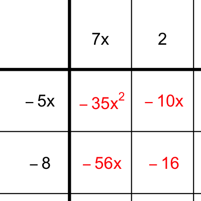

Or, you can FOIL...

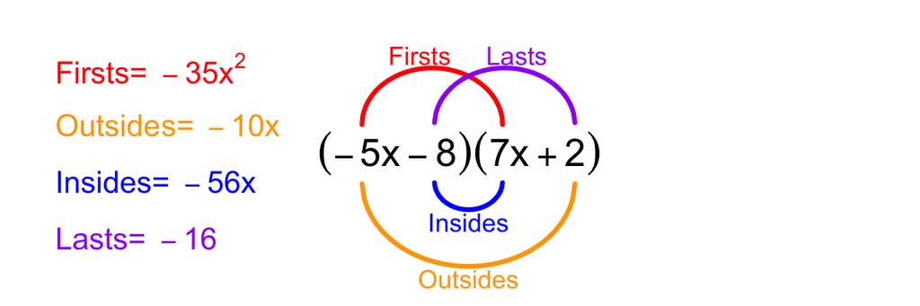

Either way, you should first get
$${-35}x^{2}-{10}x-{56}x-{16}$$

And, after combining like terms, you should get
$${-35}x^{2}-{66}x-{16}$$

Thus, $a=-35$ and $b=-66$ and $c=-16$. This question specifically asked for the value of $a$, so the answer is $-35$.

Consider the following product of linear binomials:

$$({8}x-{2})({7}x+{2})$$

When the expression is expanded and like terms are combined, an equivalent expression can be expressed in standard form:

$$ax^2+bx+c$$

where $a$, $b$, and $c$ are integers.

- What is the value of $a$?

You could use the box method.

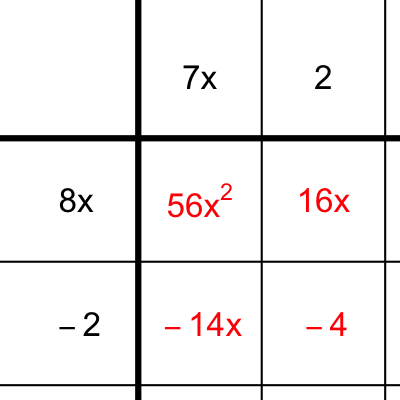

Or, you can FOIL...

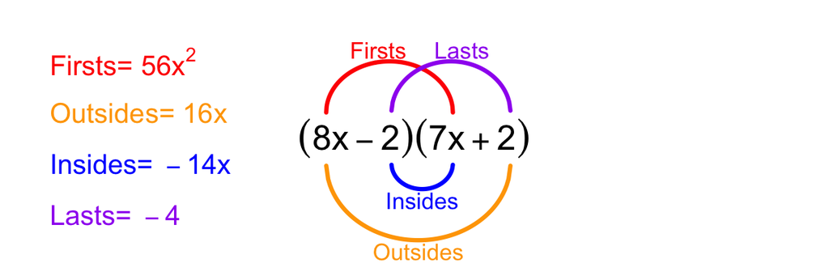

Either way, you should first get
$${56}x^{2}+{16}x-{14}x-{4}$$

And, after combining like terms, you should get
$${56}x^{2}+{2}x-{4}$$

Thus, $a=56$ and $b=2$ and $c=-4$. This question specifically asked for the value of $a$, so the answer is $56$.

Consider the following product of linear binomials:

$$({-9}x+{3})(-x-{5})$$

When the expression is expanded and like terms are combined, an equivalent expression can be expressed in standard form:

$$ax^2+bx+c$$

where $a$, $b$, and $c$ are integers.

- What is the value of $a$?

You could use the box method.

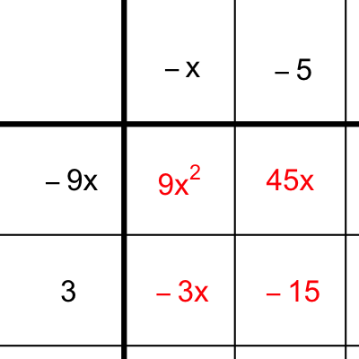

Or, you can FOIL...

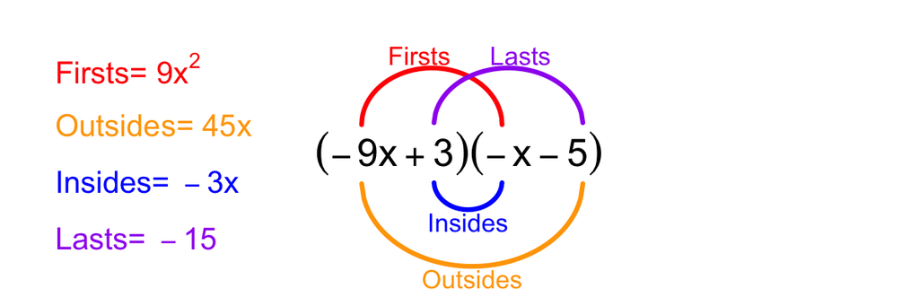

Either way, you should first get
$${9}x^{2}+{45}x-{3}x-{15}$$

And, after combining like terms, you should get
$${9}x^{2}+{42}x-{15}$$

Thus, $a=9$ and $b=42$ and $c=-15$. This question specifically asked for the value of $a$, so the answer is $9$.

Consider the following product of linear binomials:

$$({-6}x-{3})({-4}x+{5})$$

When the expression is expanded and like terms are combined, an equivalent expression can be expressed in standard form:

$$ax^2+bx+c$$

where $a$, $b$, and $c$ are integers.

- What is the value of $a$?

You could use the box method.

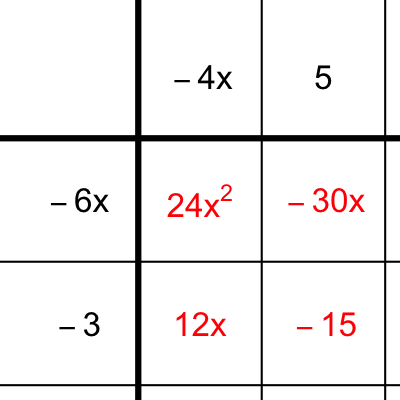

Or, you can FOIL...

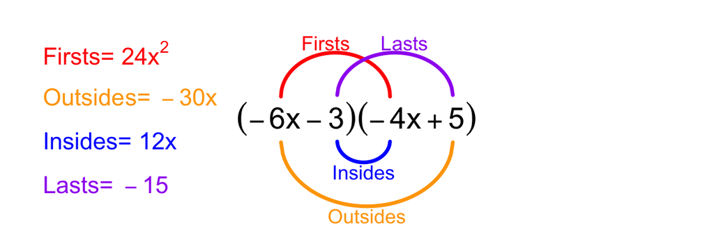

Either way, you should first get
$${24}x^{2}-{30}x+{12}x-{15}$$

And, after combining like terms, you should get
$${24}x^{2}-{18}x-{15}$$

Thus, $a=24$ and $b=-18$ and $c=-15$. This question specifically asked for the value of $a$, so the answer is $24$.

Consider the following product of linear binomials:

$$({-2}x+{4})({7}x+{7})$$

When the expression is expanded and like terms are combined, an equivalent expression can be expressed in standard form:

$$ax^2+bx+c$$

where $a$, $b$, and $c$ are integers.

- What is the value of $a$?

You could use the box method.

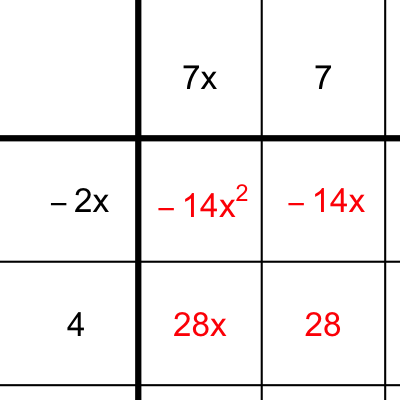

Or, you can FOIL...

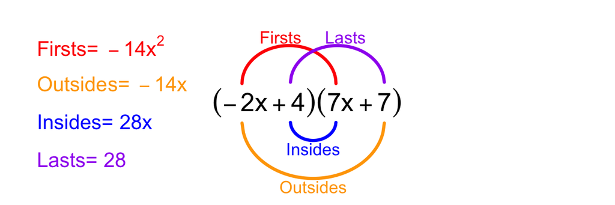

Either way, you should first get
$${-14}x^{2}-{14}x+{28}x+{28}$$

And, after combining like terms, you should get
$${-14}x^{2}+{14}x+{28}$$

Thus, $a=-14$ and $b=14$ and $c=28$. This question specifically asked for the value of $a$, so the answer is $-14$.

Consider the following product of linear binomials:

$$({9}x+{4})({-5}x-{6})$$

When the expression is expanded and like terms are combined, an equivalent expression can be expressed in standard form:

$$ax^2+bx+c$$

where $a$, $b$, and $c$ are integers.

- What is the value of $a$?

You could use the box method.

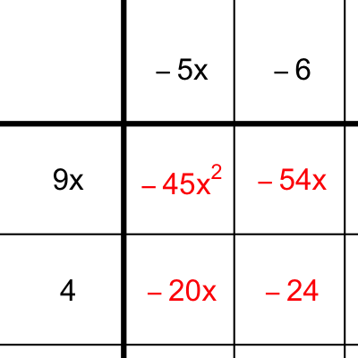

Or, you can FOIL...

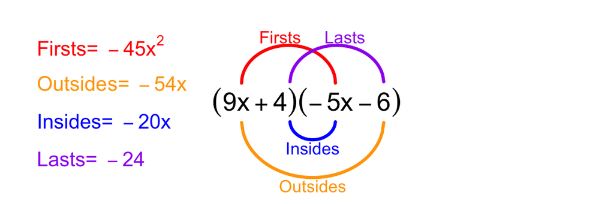

Either way, you should first get
$${-45}x^{2}-{54}x-{20}x-{24}$$

And, after combining like terms, you should get
$${-45}x^{2}-{74}x-{24}$$

Thus, $a=-45$ and $b=-74$ and $c=-24$. This question specifically asked for the value of $a$, so the answer is $-45$.

Consider the following product of linear binomials:

$$({8}x-{3})({8}x+{5})$$

When the expression is expanded and like terms are combined, an equivalent expression can be expressed in standard form:

$$ax^2+bx+c$$

where $a$, $b$, and $c$ are integers.

- What is the value of $a$?

You could use the box method.

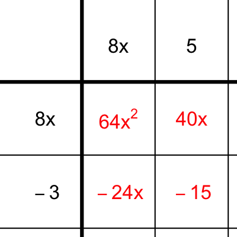

Or, you can FOIL...

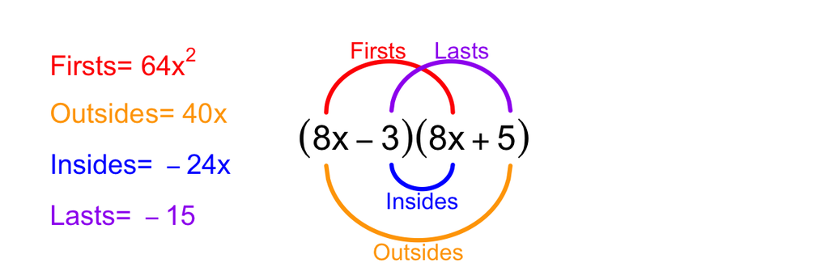

Either way, you should first get
$${64}x^{2}+{40}x-{24}x-{15}$$

And, after combining like terms, you should get
$${64}x^{2}+{16}x-{15}$$

Thus, $a=64$ and $b=16$ and $c=-15$. This question specifically asked for the value of $a$, so the answer is $64$.

Consider the following product of linear binomials:

$$({-8}x+{6})(x+{3})$$

When the expression is expanded and like terms are combined, an equivalent expression can be expressed in standard form:

$$ax^2+bx+c$$

where $a$, $b$, and $c$ are integers.

- What is the value of $a$?

You could use the box method.

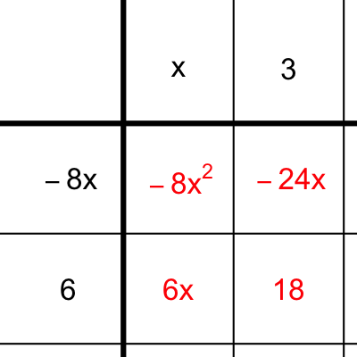

Or, you can FOIL...

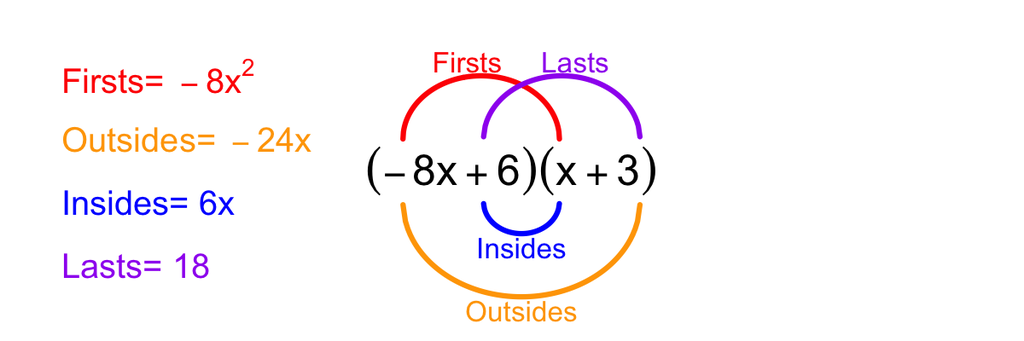

Either way, you should first get
$${-8}x^{2}-{24}x+{6}x+{18}$$

And, after combining like terms, you should get
$${-8}x^{2}-{18}x+{18}$$

Thus, $a=-8$ and $b=-18$ and $c=18$. This question specifically asked for the value of $a$, so the answer is $-8$.

Consider the following product of linear binomials:

$$(-x+{4})({7}x-{4})$$

When the expression is expanded and like terms are combined, an equivalent expression can be expressed in standard form:

$$ax^2+bx+c$$

where $a$, $b$, and $c$ are integers.

- What is the value of $b$?

You could use the box method.

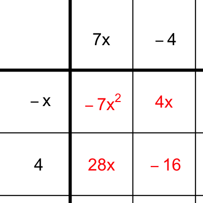

Or, you can FOIL...

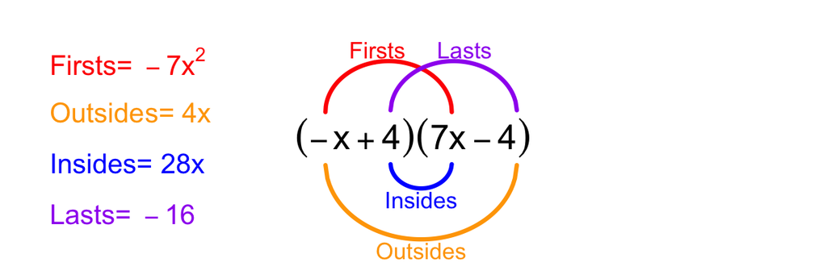

Either way, you should first get
$${-7}x^{2}+{4}x+{28}x-{16}$$

And, after combining like terms, you should get
$${-7}x^{2}+{32}x-{16}$$

Thus, $a=-7$ and $b=32$ and $c=-16$. This question specifically asked for the value of $b$, so the answer is $32$.

Consider the following product of linear binomials:

$$({-2}x-{6})({8}x-{7})$$

When the expression is expanded and like terms are combined, an equivalent expression can be expressed in standard form:

$$ax^2+bx+c$$

where $a$, $b$, and $c$ are integers.

- What is the value of $b$?

You could use the box method.

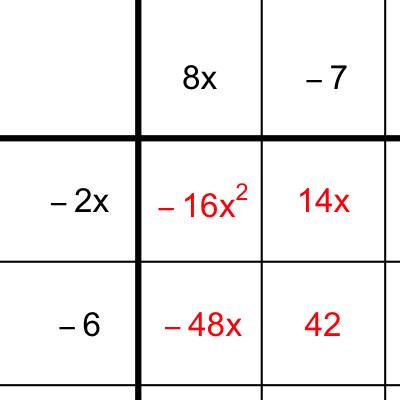

Or, you can FOIL...

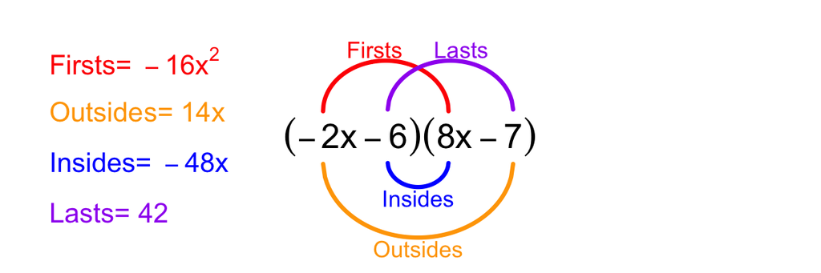

Either way, you should first get
$${-16}x^{2}+{14}x-{48}x+{42}$$

And, after combining like terms, you should get
$${-16}x^{2}-{34}x+{42}$$

Thus, $a=-16$ and $b=-34$ and $c=42$. This question specifically asked for the value of $b$, so the answer is $-34$.

Consider the following product of linear binomials:

$$({7}x+{1})({4}x-{8})$$

When the expression is expanded and like terms are combined, an equivalent expression can be expressed in standard form:

$$ax^2+bx+c$$

where $a$, $b$, and $c$ are integers.

- What is the value of $b$?

You could use the box method.

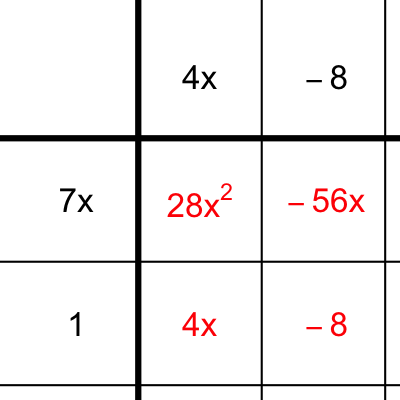

Or, you can FOIL...

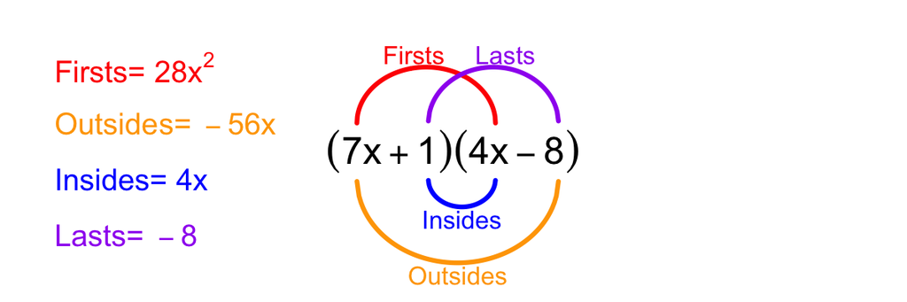

Either way, you should first get
$${28}x^{2}-{56}x+{4}x-{8}$$

And, after combining like terms, you should get
$${28}x^{2}-{52}x-{8}$$

Thus, $a=28$ and $b=-52$ and $c=-8$. This question specifically asked for the value of $b$, so the answer is $-52$.

Consider the following product of linear binomials:

$$({-2}x-{8})({3}x+{7})$$

When the expression is expanded and like terms are combined, an equivalent expression can be expressed in standard form:

$$ax^2+bx+c$$

where $a$, $b$, and $c$ are integers.

- What is the value of $b$?

You could use the box method.

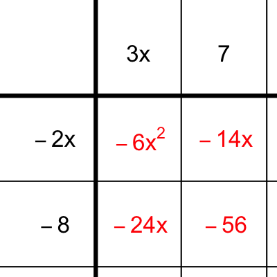

Or, you can FOIL...

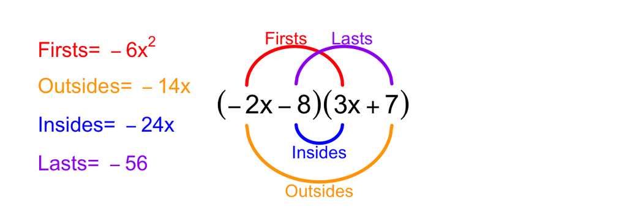

Either way, you should first get
$${-6}x^{2}-{14}x-{24}x-{56}$$

And, after combining like terms, you should get
$${-6}x^{2}-{38}x-{56}$$

Thus, $a=-6$ and $b=-38$ and $c=-56$. This question specifically asked for the value of $b$, so the answer is $-38$.

Consider the following product of linear binomials:

$$({-8}x-{9})({3}x-{5})$$

When the expression is expanded and like terms are combined, an equivalent expression can be expressed in standard form:

$$ax^2+bx+c$$

where $a$, $b$, and $c$ are integers.

- What is the value of $b$?

You could use the box method.

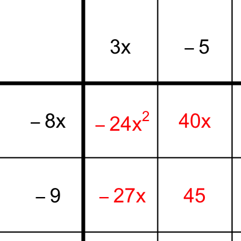

Or, you can FOIL...

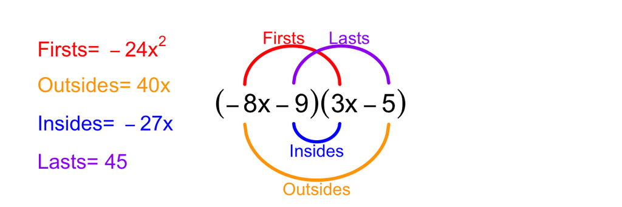

Either way, you should first get
$${-24}x^{2}+{40}x-{27}x+{45}$$

And, after combining like terms, you should get
$${-24}x^{2}+{13}x+{45}$$

Thus, $a=-24$ and $b=13$ and $c=45$. This question specifically asked for the value of $b$, so the answer is $13$.

Consider the following product of linear binomials:

$$({6}x-{6})(-x-{7})$$

When the expression is expanded and like terms are combined, an equivalent expression can be expressed in standard form:

$$ax^2+bx+c$$

where $a$, $b$, and $c$ are integers.

- What is the value of $b$?

You could use the box method.

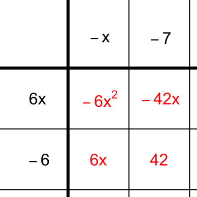

Or, you can FOIL...

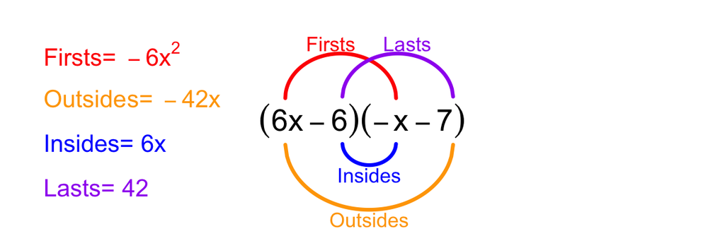

Either way, you should first get
$${-6}x^{2}-{42}x+{6}x+{42}$$

And, after combining like terms, you should get
$${-6}x^{2}-{36}x+{42}$$

Thus, $a=-6$ and $b=-36$ and $c=42$. This question specifically asked for the value of $b$, so the answer is $-36$.

Consider the following product of linear binomials:

$$({-9}x-{7})({4}x-{9})$$

When the expression is expanded and like terms are combined, an equivalent expression can be expressed in standard form:

$$ax^2+bx+c$$

where $a$, $b$, and $c$ are integers.

- What is the value of $b$?

You could use the box method.

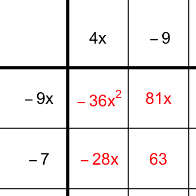

Or, you can FOIL...

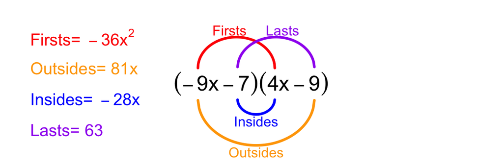

Either way, you should first get
$${-36}x^{2}+{81}x-{28}x+{63}$$

And, after combining like terms, you should get
$${-36}x^{2}+{53}x+{63}$$

Thus, $a=-36$ and $b=53$ and $c=63$. This question specifically asked for the value of $b$, so the answer is $53$.

Consider the following product of linear binomials:

$$({5}x-{8})({-6}x+{8})$$

When the expression is expanded and like terms are combined, an equivalent expression can be expressed in standard form:

$$ax^2+bx+c$$

where $a$, $b$, and $c$ are integers.

- What is the value of $b$?

You could use the box method.

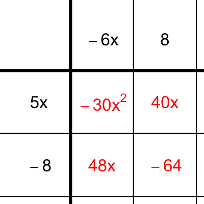

Or, you can FOIL...

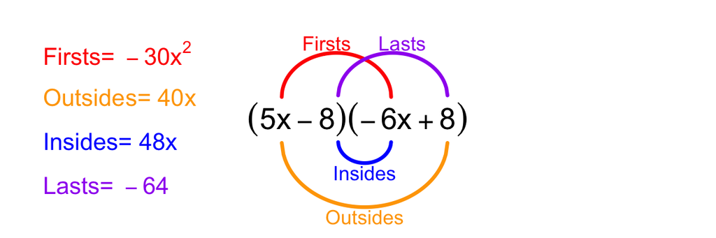

Either way, you should first get
$${-30}x^{2}+{40}x+{48}x-{64}$$

And, after combining like terms, you should get
$${-30}x^{2}+{88}x-{64}$$

Thus, $a=-30$ and $b=88$ and $c=-64$. This question specifically asked for the value of $b$, so the answer is $88$.